# Exploratory data analysis on built-in datasets: 2013 NYC Flights and US states

Rohan Thakkar

October 30, 2015

```r
# Stardard libraries

library(tidyr)
library(dplyr)
library(ggplot2)
library(nycflights13)
library(plyr)

# Allowing local data frame access to flights, weather and planes datasets for better visualization
flights <- tbl_df(flights)
weather <- tbl_df(weather)
planes <- tbl_df(planes)
```

#### Problem 1: Exploring the NYC Flights Data

In this problem set we will continue to use the data on all flights that departed NYC (i.e. JFK, LGA or EWR) in 2013. You can find this data as part of the `nycflights13` R package. Data includes not only information about flights, but also data about planes, airports, weather, and airlines. Load the data and use it to answer the following questions.

##### (a) Flights are often delayed. Perform an exploratory data analysis to address each of the following questions:

- **What was the worst day to fly out of NYC in 2013 if you dislike delayed flights?**

If I disliked delayed flights, the worst day for me to fly out of NYC in 2013 would be the one with the highest value of **average** departure delay per flight on that day (Only flights with **positive** departure delays included)

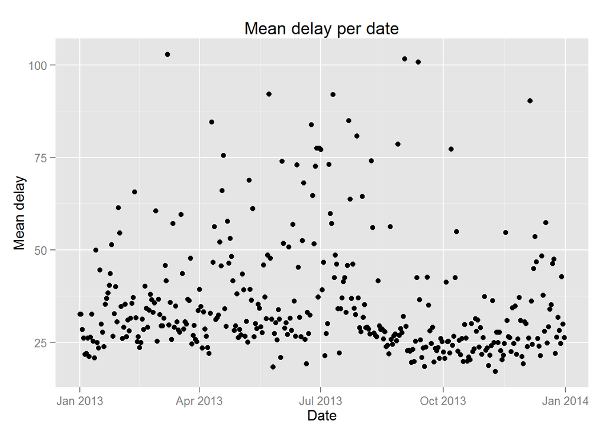

*As we can see in the scatterplot above, the worst day to fly out of NYC would be the value on X-axis corresponding to the highest value for Y-axis, which in this case seems to be somewhere around March. To obtain the accurate date, we can look up the dataset arranged in descending order of mean departure delays.*

```
##         date mean_delay
## 1 2013-03-08   102.9035
```

*Thus, we can see that our observation from the scatterplot was correct and the worst day to fly out of NYC in 2013 according to our logic is indeed in March, i.e., 2013-03-08 (8th March, 2013)*

- **Are there any seasonal patterns in departure delays for flights from NYC?**

Taking 3 months as a season as it occurs in NYC -

1. Winter (December - February)
2. Spring (March - May)
3. Summer (June - August)
4. Fall (September - November)

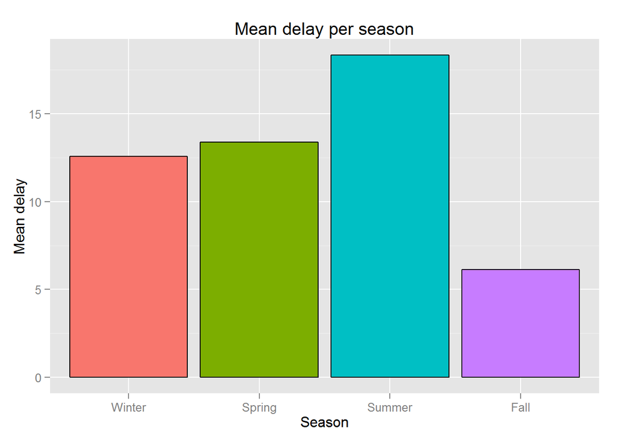

*Thus, we can see in the bar graph that the average delay is the highest during summer (June - August) and the lowest average delay is observed during Fall (September - November)*

- **On average, how do departure delays vary over the course of a day?**

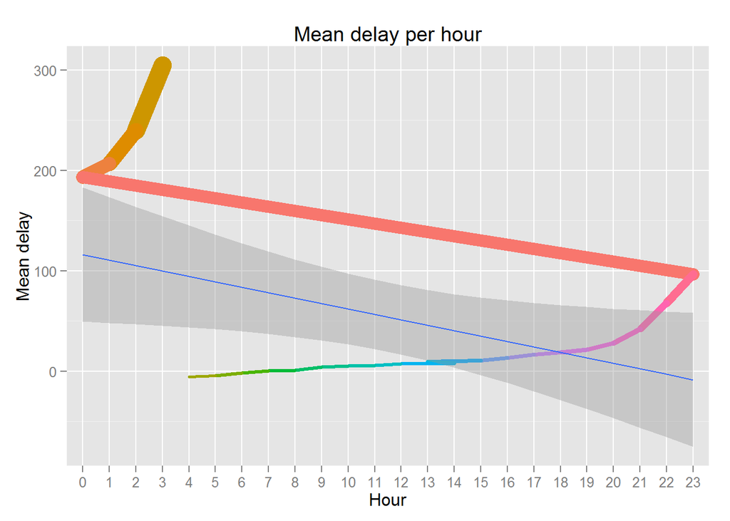

##### (b) Flight delays are often linked to weather conditions. How does weather impact flights from NYC? Utilize both the `flights` and `weather` datasets to explore this question. Include at least one visualization to aid in communicating what you find.

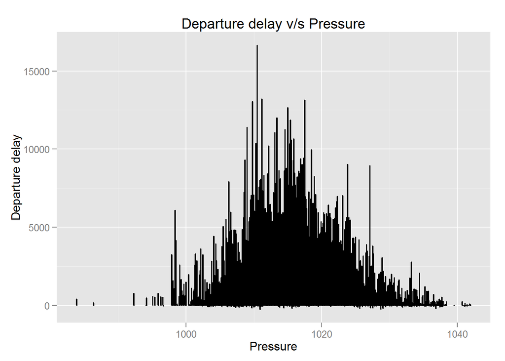

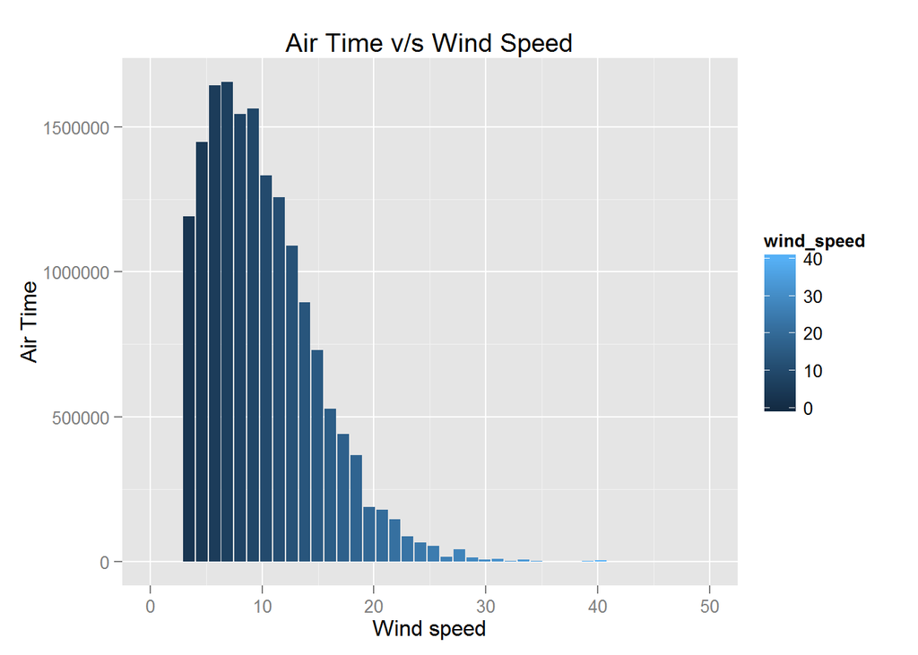

*Similarly, the function of Air time of a flight v/s the wind speed at the origin forms a heap-like structure with the air time being at its maxima when the wind speed is around 7. As and when the wind speed increases or decreases from 7, the air time declines*

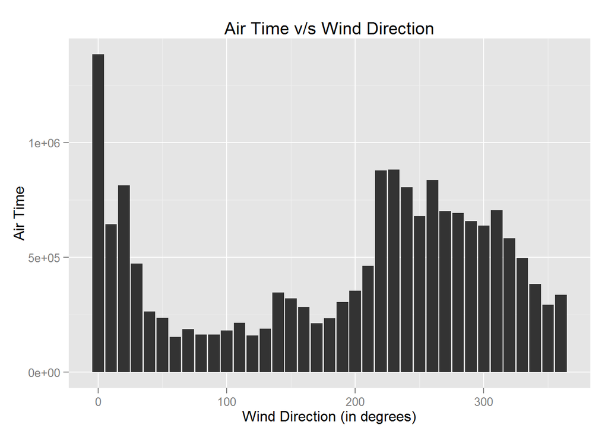

##### (c) Flight performance may also be impacted by the aircraft used. Do aircrafts with certain characteristics (e.g. manufacturer) demonstrate better performance? Utilize both the `flights` and `planes` datasets to explore this question. Include at least one visualization to aid in communicating what you find.

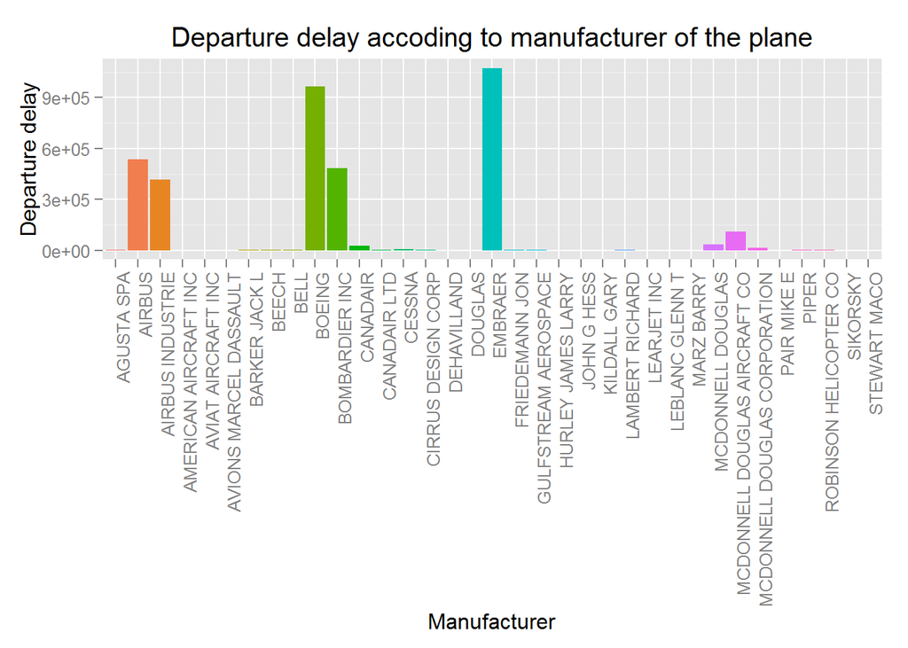

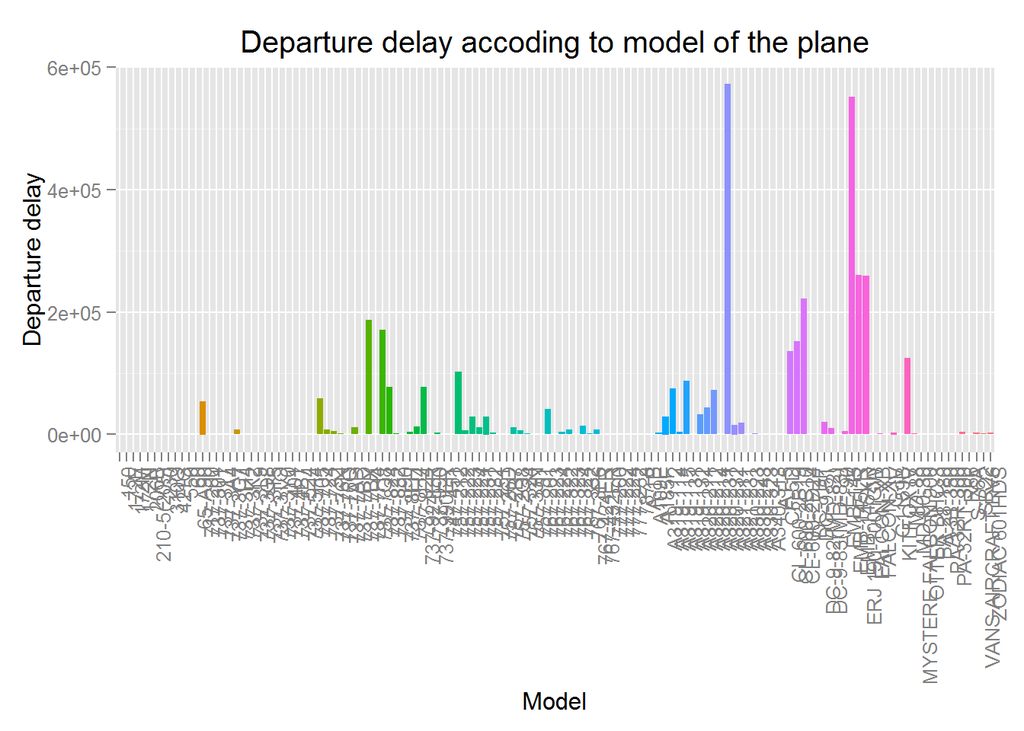

*Similarly, we can see that the departure delay highly depends on the model of the plane as well, with 767-223 being one of those having the least departure delay, whereas A320-232 having the highest departure delay. This suggests that A320-232 air planes need more time to set the plane ready before they take off, whereas 767-223 is one of the more optimal ones in the same aspect.*

**Conclusion -** As one can expect, there is a strong impact of the planes and the weather at origin on the flights data. R helps us identify the ones with the strongest effect among all.

#### Problem 2:

In this problem we will use the `state` dataset, available as part of the R statistical computing platforms. Load the data and use it to answer the following questions.

##### (a) Describe the data and each variable it contains. Tidy the data, preparing it for an exploratory data analysis.

```r
#Loading the 'state' dataset
data(state)
```

The ‘state’ dataset is essentially a collection of 3 vectors (state.abb, state.area, state.name), 2 factors (state.division and state.region), 1 list (state.center) and 1 table (state.x77)

The detailed explanation of each is as follows -

The *‘state.abb’* dataset represents the character vector of 2-letter abbreviations for the state names -

```
## [1] "AL" "AK" "AZ" "AR" "CA" "CO"
```

The *‘state.area’* dataset represents the numeric vector of state areas (in square miles) -

```
## [1]  51609 589757 113909  53104 158693 104247
```

The *‘state.center’* dataset represents the list with components named x and y giving the approximate geographic center of each state in negative longitude and latitude -

```
## $x
##  [1]  -86.7509 -127.2500 -111.6250  -92.2992 -119.7730 -105.5130  -72.3573
##  [8]  -74.9841  -81.6850  -83.3736 -126.2500 -113.9300  -89.3776  -86.0808
## [15]  -93.3714  -98.1156  -84.7674  -92.2724  -68.9801  -76.6459  -71.5800
## [22]  -84.6870  -94.6043  -89.8065  -92.5137 -109.3200  -99.5898 -116.8510
## [29]  -71.3924  -74.2336 -105.9420  -75.1449  -78.4686 -100.0990  -82.5963
## [36]  -97.1239 -120.0680  -77.4500  -71.1244  -80.5056  -99.7238  -86.4560
## [43]  -98.7857 -111.3300  -72.5450  -78.2005 -119.7460  -80.6665  -89.9941
## [50] -107.2560
##
## $y
##  [1] 32.5901 49.2500 34.2192 34.7336 36.5341 38.6777 41.5928 38.6777
##  [9] 27.8744 32.3329 31.7500 43.5648 40.0495 40.0495 41.9358 38.4204
## [17] 37.3915 30.6181 45.6226 39.2778 42.3645 43.1361 46.3943 32.6758
## [25] 38.3347 46.8230 41.3356 39.1063 43.3934 39.9637 34.4764 43.1361
## [33] 35.4195 47.2517 40.2210 35.5053 43.9078 40.9069 41.5928 33.6190
## [41] 44.3365 35.6767 31.3897 39.1063 44.2508 37.5630 47.4231 38.4204
## [49] 44.5937 43.0504
```

The *‘state.division’* dataset represents the factor giving state divisions (New England, Middle Atlantic, South Atlantic, East South Central, West South Central, East North Central, West North Central, Mountain, and Pacific) -

```
## [1] East South Central Pacific            Mountain
## [4] West South Central Pacific            Mountain
## 9 Levels: New England Middle Atlantic ... Pacific
```

The *‘state.name’* dataset represents the character vector giving the full state names -

```
## [1] "Alabama"    "Alaska"     "Arizona"    "Arkansas"   "California"
## [6] "Colorado"
```

The *‘state.region’* dataset represents the factor giving the region (Northeast, South, North Central, West) that each state belongs to -

```
## [1] South West  West  South West  West
## Levels: Northeast South North Central West
```

The *‘state.x77’* dataset represents an outdated data about the 50 states in the U.S. with columns such as -

```
##            Population Income Illiteracy Life Exp Murder HS Grad Frost
## Alabama          3615   3624        2.1    69.05   15.1    41.3    20
## Alaska            365   6315        1.5    69.31   11.3    66.7   152
## Arizona          2212   4530        1.8    70.55    7.8    58.1    15
## Arkansas         2110   3378        1.9    70.66   10.1    39.9    65
## California      21198   5114        1.1    71.71   10.3    62.6    20
## Colorado         2541   4884        0.7    72.06    6.8    63.9   166
##              Area
## Alabama     50708
## Alaska     566432
## Arizona    113417
## Arkansas    51945
## California 156361
## Colorado   103766
```

- “Population” represents the population (in 1000s) of a state as of July 1, 1975
- “Income” represents the per capita income (in 1974)
- “Illiteracy” represents the illiteracy rate of individuals in a state (1970)
- “Life Exp” represents the average life expectancy of an individual in a state (1969 to 1971)
- “Murder” represents the murder and non-negligent manslaughter rate per 100,000 people in a state (1976)
- “HS Grad” represents the high school graduation rate (in percentage) of children in a state (1970)
- “Frost” represents the mean number of days with minimum temperature below freezing (1931 to 1960)
- “Area” represents the total surface area of a state in square miles.

We create a matrix ‘state’ that combines all variables of state so as to perform analysis. Since the analysis is working fine with matrix, I won’t convert it to a data-frame.

##### (b) Develop one research question of your own that you can address using the `state` dataset. Clearly state the question you are going to address. Provide at least two visualizations to support your exploration of this question. Discuss what you find.

**Does the per capita income of a state depend upon any of its other parameters?**

[A] Based on illiteracy:

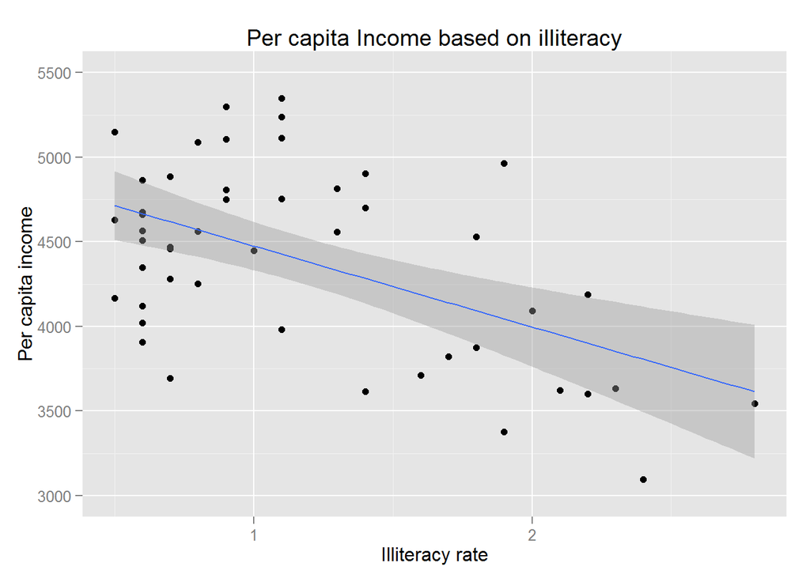

*Thus, we can see from the plot that the per capita income of a state is generally high which has a low illiteracy rate.*

[B] Based on high school gradutation rate of students

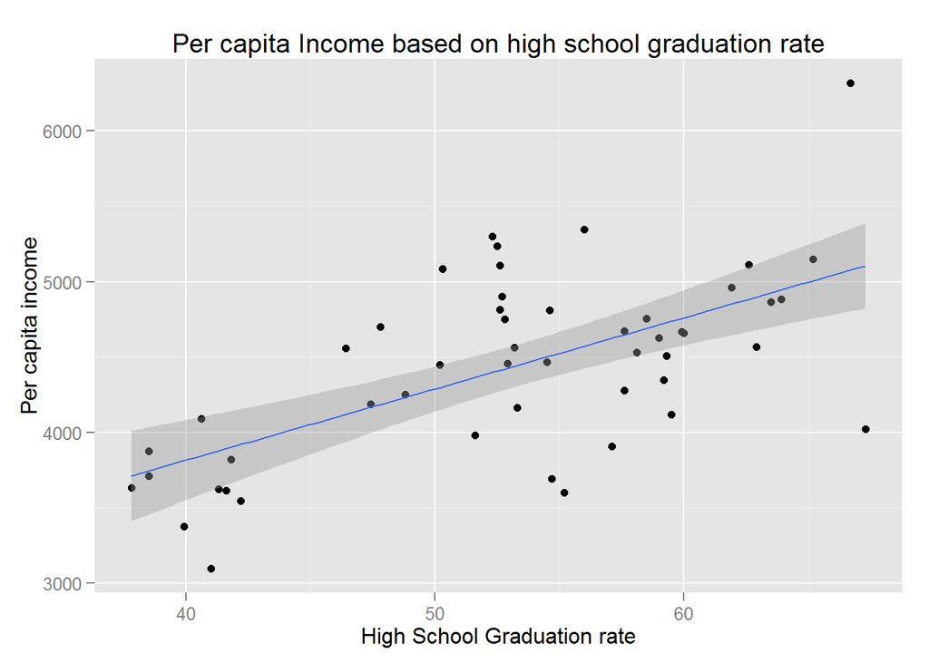

*Similarly, we can see from the plot that the per capita income of a state is generally high which has a high high school graduation rate.*

**Does the illiteracy rate in a state affect the murder rate?**

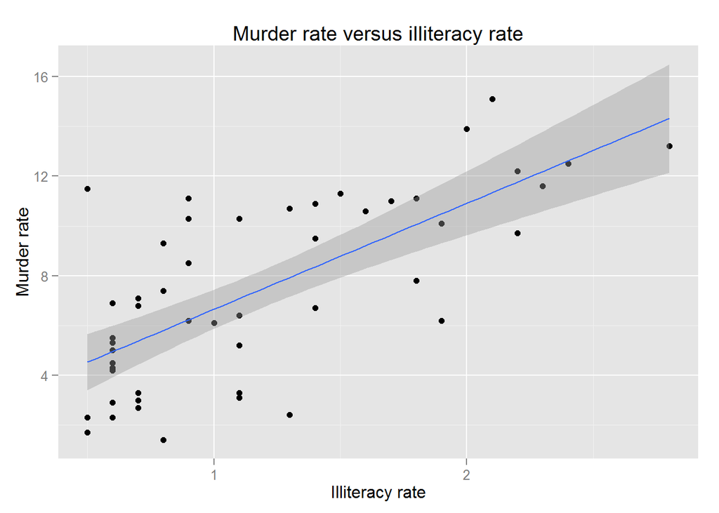

*As expected, the states which have a high illiteracy rate also have a high murder rate and vice-versa. This plot succicntly demonstrated the value of education on an individual’s morals.*

**Does life expectancy depend on any factor?**

One might guess that since frost denotes the mean number of days when the temperature was below freezing, that might have a negative impact on the average life expectancy so we plot the two variables.

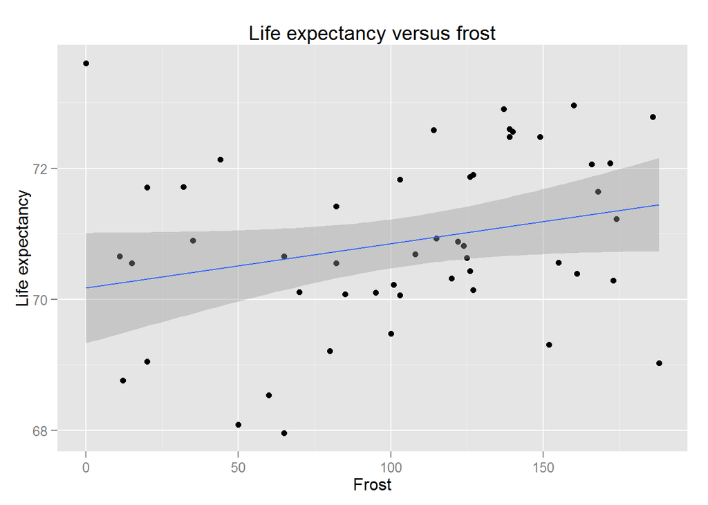

*Surprisingly, frost has a direct relationship with life expectancy - with the life expectancy increasing as the frost increases.*

**Conclusion** - There are various predictable and unpredictable dependancies between the different characteristics of a state and using R Studio, we can easily interpret those to verify our understanding about this data and explore surprising relationships between its variables.

In case you need to contact me, please feel free to shoot me an email at rohan27@uw.edu

*Thank you for viewing!*